# A novel role for alkyladenine DNA glycosylase in regulating alkylation-induced ER stress

Figure 1, Panels C and D

L Milano, CF Charlier, R Andreguetti, T Cox, E Healing, MP Thomé, RM Elliott, JY Masson, LD Samson, JY Masson, G Lenz, JAP Henriques, A Nohturfft and LB Meira

Note: This analysis requires input data generated by an earlier script.

## Setup

- Clear memory and console
- Load packages
- Get current script name

```r
# Clear memory
rm(list=setdiff(ls(all=TRUE), c(".Random.seed")))
# Clear console
cat("\014")
```

```r
this.script <- rstudioapi::getActiveDocumentContext()$path %>% basename
cat("Script:", this.script)
```

```
Script: 04_Figure_1_CD.Rmd
```

## Load data

### Load toptables generated in previous script:

```r
xlsx.file <- "Supplemental_Data_1.xlsx"
stopifnot(file.exists(xlsx.file))
sheet.names <- openxlsx::getSheetNames(xlsx.file)
tt <- lapply(sheet.names, function(s.name) {
   res <- openxlsx::read.xlsx(xlsxFile = xlsx.file, sheet=s.name) %>%
     dplyr::select(SYMBOL, logFC, adj.P.Val) %>%
     dplyr::filter(complete.cases(.)) %>%
     dplyr::group_by(SYMBOL) %>%
     dplyr::slice(base::which.min(adj.P.Val)) %>%
     dplyr::ungroup(.)
   res
}) %>%
  set_names(sheet.names)
```

```r
cat("File read:", xlsx.file)
```

```
File read: Supplemental_Data_1.xlsx
```

```r
rm(xlsx.file)
```

### Load mouse/human gene symbol map

```r
map.file <- "./data/mouse_human_symbols_2018_03_05b.txt.gz"
stopifnot(file.exists(map.file))
gs.ms.hu <- read.table(file=map.file, sep="\t", header=TRUE,
                       stringsAsFactors = FALSE)
head(gs.ms.hu)
```

|  | mouse | human |
| --- | --- | --- |
| 1 | 0610009B22Rik | TRAPPC2B |
| 2 | 0610009B22Rik | TRAPPC2 |
| 3 | 0610009O20Rik | KIAA0141 |
| 4 | 0610010F05Rik | KIAA1841 |
| 5 | 0610010K14Rik | C17orf49 |
| 6 | 0610010K14Rik | RNASEK-C17orf49 |

### Load gene ontology (GO) data

The original input file was obtained from the [enrichr](https://maayanlab.cloud/Enrichr/) website ([Chen et al., 2013](https://pubmed.ncbi.nlm.nih.gov/23586463/); [Kuleshov et al., 2016](https://pubmed.ncbi.nlm.nih.gov/27141961/)).

```r
enrichr.GO_Biological_Process.file <- "./data/GO_Biological_Process_2015.txt.gz"
stopifnot(file.exists(enrichr.GO_Biological_Process.file))
search.pattern <- "endoplasmic reticulum unfolded protein response \\(GO:0030968\\)"
go.0030968.hu <- readLines(con=enrichr.GO_Biological_Process.file) %>%
  grep(pattern=search.pattern, x=., invert = FALSE, value=TRUE) %>%
  strsplit(., split="\t") %>% .[[1]] %>% .[-(1:2)]
cat("File read:", enrichr.GO_Biological_Process.file)
```

```
File read: ./data/GO_Biological_Process_2015.txt.gz
```

```r
rm(enrichr.GO_Biological_Process.file, search.pattern)
```

```r
go.0030968.ms <- subset(gs.ms.hu, human %in% go.0030968.hu) %>%
  .$mouse %>% unique %>% sort
cat("Number of GO:0030968 genes:", length(go.0030968.ms))
```

```
Number of GO:0030968 genes: 80
```

```r
rm(go.0030968.hu)
```

### Load Xbp1 ChIP-seq data

The Xbp1 ChIP-seq targets were published by Argemí et al.(2017) ([Pubmed](https://www.ncbi.nlm.nih.gov/pubmed/28082079)) ([GEO](https://www.ncbi.nlm.nih.gov/geo/query/acc.cgi?acc=GSE86048)).  
Data were downloaded from [ChIP-Atlas](http://chip-atlas.org/) and saved as a tsv file.

Sample information was obtained from ChIP-Atlas:

```r
argemi.samples <- data.frame(
  SRX = c("SRX2053270", "SRX2053271",
          "SRX2053272", "SRX2053273",
          "SRX2053274", "SRX2053275",
          "SRX2053276", "SRX2053277"),
  GSM = c("GSM2292554", "GSM2292555",
          "GSM2292556", "GSM2292557",
          "GSM2292558", "GSM2292559",
          "GSM2292560", "GSM2292561"),
  source_name = c("normal liver",
                  "liver: 7d after XBP1 silencing",
                  "liver: 6h after partial hepatectomy",
                  "liver: 7d after XBP1 silencing and 6h after partial hepatectomy",
                  "liver: 48h after partial hepatectomy",
                  "liver: 7d after XBP1 silencing and 48h after partial hepatectomy",
                  "liver: 6h after sham operation",
                  "liver: 48h after sham operation")
)
argemi.samples$GEO <- paste0("<a href='https://www.ncbi.nlm.nih.gov/geo/query/acc.cgi?acc=", argemi.samples$GSM, "'>",
                             argemi.samples$GSM, "</a>")
argemi.samples %>% dplyr::select(SRX, GEO, source_name) %>%
  DT::datatable(., rownames = F, options = list(dom = 't'), escape=F)
```

| SRX | GEO | source_name |
| --- | --- | --- |
| SRX2053270 | GSM2292554 | normal liver |
| SRX2053271 | GSM2292555 | liver: 7d after XBP1 silencing |
| SRX2053272 | GSM2292556 | liver: 6h after partial hepatectomy |
| SRX2053273 | GSM2292557 | liver: 7d after XBP1 silencing and 6h after partial hepatectomy |
| SRX2053274 | GSM2292558 | liver: 48h after partial hepatectomy |
| SRX2053275 | GSM2292559 | liver: 7d after XBP1 silencing and 48h after partial hepatectomy |
| SRX2053276 | GSM2292560 | liver: 6h after sham operation |
| SRX2053277 | GSM2292561 | liver: 48h after sham operation |

Download ChIP-seq data at maximum 1kb from transcription start site:

```r
xbp1.chip.seq.file <- "./data/chip_atlas_XBP1_mouse_1kb.tsv.gz"
stopifnot(file.exists(xbp1.chip.seq.file))
chip.atlas.1kb <- read.table(file=xbp1.chip.seq.file, sep="\t", header=T, stringsAsFactors = F)
cat("File read:", xbp1.chip.seq.file)
```

```
File read: ./data/chip_atlas_XBP1_mouse_1kb.tsv.gz
```

```r
names(chip.atlas.1kb) <- sub("\\.Liver$", "", names(chip.atlas.1kb))
rm(xbp1.chip.seq.file)
```

Select control samples and those where ER stress was induced through partial hepatectomy:

```r
chip.samples <- c("SRX2053270", "SRX2053272", "SRX2053274")
argemi.samples.select.1 <- argemi.samples %>%
  dplyr::select(SRX, GEO, source_name) %>%
  dplyr::filter(SRX %in% chip.samples)
DT::datatable(argemi.samples.select.1, rownames = F, options = list(dom = 't'), escape=F)
```

| SRX | GEO | source_name |
| --- | --- | --- |
| SRX2053270 | GSM2292554 | normal liver |
| SRX2053272 | GSM2292556 | liver: 6h after partial hepatectomy |
| SRX2053274 | GSM2292558 | liver: 48h after partial hepatectomy |

ChIP-seq filtering parameters:

```r
q.min <- 2000
cat("Maximum q-value: <b>", q.min, "</b><br>\n", sep="")
```

Maximum q-value: **2000**

Number of target genes in each of the 3 samples:

```r
chip.atlas.1kb.select <- chip.atlas.1kb[,c("Target_genes", chip.samples)]
tmp <-sapply(chip.samples, function(srx) {
  chip.atlas.1kb.select[,c("Target_genes", srx)] %>%
  magrittr::set_colnames(c("genes", "sample")) %>%
  dplyr::filter(sample >= q.min) %>%
    .$genes %>% unique %>% length
})
chip.atlas.1kb.select.df <- data.frame(SRX=names(tmp), target.count=tmp)
argemi.samples.select.2 <- merge(x=argemi.samples.select.1, y=chip.atlas.1kb.select.df, by="SRX")
DT::datatable(argemi.samples.select.2, rownames = F, options = list(dom = 't'), escape=F)
```

| SRX | GEO | source_name | target.count |
| --- | --- | --- | --- |
| SRX2053270 | GSM2292554 | normal liver | 12 |
| SRX2053272 | GSM2292556 | liver: 6h after partial hepatectomy | 346 |
| SRX2053274 | GSM2292558 | liver: 48h after partial hepatectomy | 131 |

```r
rm(tmp, chip.atlas.1kb.select.df)
```

Select Xbp1 targets identified in any of the three samples:

```r
xbp1.chipseq.targets <- lapply(chip.samples, function(srx, cutoff.q, chip.atlas.1kb) {
  chip.atlas.1kb[, c("Target_genes", srx)] %>%
    magrittr::set_colnames(c("genes", "sample")) %>%
    dplyr::filter(sample >= q.min) %>%
    .$genes %>% unique %>% sort
}, cutoff.q=cutoff.q, chip.atlas.1kb=chip.atlas.1kb) %>%
  unlist %>% unique %>% sort
cat("Number of Xbp1 targets selected:<b>", length(xbp1.chipseq.targets), "</b><br>\n")
```

Number of Xbp1 targets selected: **353**

### Load Xbp1 correlation network data from Genecan

These data were described in [Brignull et al., 2013](https://doi.org/10.1186/1471-2164-14-853).  
Genecan website: http://genecan.sgul.ac.uk/.  
Selecting 100 most strongly correlated genes.

```r
genecan.file.mouse.Xbp1 <- "./data/rMean_GPL1261_cvmin5_19Apr2012_1334842595_Xbp1.txt.gz"
stopifnot(file.exists(genecan.file.mouse.Xbp1))
xbp1.network <- read.table(file=genecan.file.mouse.Xbp1, sep="\t", header=T, stringsAsFactors = F) %>%
    dplyr::arrange(desc(r_Mean)) %>%
    head(., 100) %>%
    .$Gene_Symbol
cat("File read:", genecan.file.mouse.Xbp1)
```

```
File read: ./data/rMean_GPL1261_cvmin5_19Apr2012_1334842595_Xbp1.txt.gz
```

```r
rm(genecan.file.mouse.Xbp1)
```

### Combine genesets to be highlighted

```r
# Combine genesets in a list object:
genesets <- list()
genesets$Xbp1.ChIPseq <- list(name="Xbp1 ChpSq", genes=xbp1.chipseq.targets)
genesets$GO_0030968 <- list(name ="GO:0030968", genes=go.0030968.ms)
genesets$Xbp1.Network <- list(name="Xbp1 Netwrk", genes=xbp1.network)
str(genesets)
```

```
List of 3
 $ Xbp1.ChIPseq:List of 2
  ..$ name : chr "Xbp1 ChpSq"
  ..$ genes: chr [1:353] "1110065P20Rik" "1700037H04Rik" "1700092M07Rik" "2410131K14Rik" ...
 $ GO_0030968  :List of 2
  ..$ name : chr "GO:0030968"
  ..$ genes: chr [1:80] "Aars" "Acadvl" "Add1" "Amfr" ...
 $ Xbp1.Network:List of 2
  ..$ name : chr "Xbp1 Netwrk"
  ..$ genes: chr [1:100] "Xbp1" "Manf" "Hspa5" "Spcs2" ...
```

## Volcano plots

```r
source("./source/volcano_plot.source.R")
```

### Plot parameters

```r
# Plotting parameters volcano 1
plot.par <- list(
  font.size = 8,
  bar.height = 0.4,
  gap.height = 0.1,
  x.max = max(c(abs(tt$wt.mms.vs.wt.ctrl$logFC), abs(tt$ko.mms.vs.ko.ctrl$logFC))), # 4.957504
  y.max = max(c(-log10(tt$wt.mms.vs.wt.ctrl$adj.P.Val), -log10(tt$wt.mms.vs.wt.ctrl$adj.P.Val))),
  highlight.colors = c("#cc1d6f", RColorBrewer::brewer.pal(9, "Set1")),
  dot.sizes = c(0.8, 0.8, 1.2, 1.2),
  alphas = rep(1, 4),
  cutoff.fc = log2(1.75),
  cutoff.adj.p = 0.05,
  colors = c("#caf2a7", "#6fcc1d", "#d4b2c2",  "#cc1d6f") # 3= "gray70"
)
details::details(plot.par, summary="Show plot parameters", lang=NULL)
```

**Show plot parameters**

$font.size [1] 8

$bar.height [1] 0.4

$gap.height [1] 0.1

$x.max [1] 4.957504

$y.max [1] 3.308954

$highlight.colors [1] “#cc1d6f” “#E41A1C” “#377EB8” “#4DAF4A” “#984EA3” “#FF7F00” “#FFFF33” “#A65628” “#F781BF” “#999999”

$dot.sizes [1] 0.8 0.8 1.2 1.2

$alphas [1] 1 1 1 1

$cutoff.fc [1] 0.8073549

$cutoff.adj.p [1] 0.05

$colors [1] “#caf2a7” “#6fcc1d” “#d4b2c2” “#cc1d6f”

### Plot panel C

```r
vp1 <- my.volcano.plot(
  dafra=tt$wt.mms.vs.wt.ctrl,
  highlight=genesets,
  title="C. Aag Wild-type",
  subtitle="Effect of MMS",
  x.max=plot.par$x.max,
  y.max=plot.par$y.max,
  bar.height=plot.par$bar.height,
  gap.height=plot.par$gap.height,
  y.intercept=-0.1,
  y.position="left",
  font.size=plot.par$font.size,
  dot.sizes = plot.par$dot.sizes,
  highlight.colors=plot.par$highlight.colors,
  alphas = plot.par$alphas,
  cutoff.fc = plot.par$cutoff.fc,
  cutoff.adj.p = plot.par$cutoff.adj.p,
  colors = plot.par$colors
  )
```

```
[1] "Xbp1 ChpSq. Not highlighted, not significant: 13306"
[1] "Xbp1 ChpSq. Not highlighted, significant: 665"
[1] "Xbp1 ChpSq. Highlighted, not significant: 256"
[1] "Xbp1 ChpSq. Highlighted, significant: 32"
```

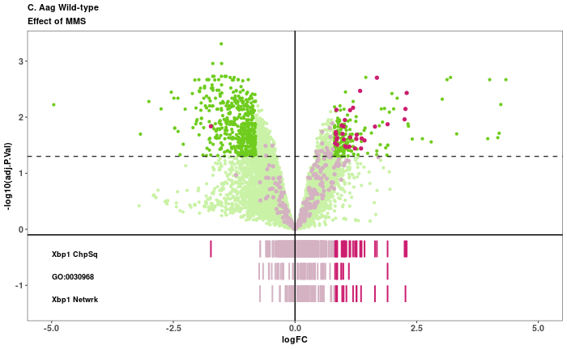

```r
vp1
```

### Plot panel D

```r
vp2 <- my.volcano.plot(
  dafra=tt$ko.mms.vs.ko.ctrl,
  highlight=genesets,
  title="D. Aag Knockout",
  subtitle="Effect of MMS",
  x.max=plot.par$x.max,
  y.max=plot.par$y.max,
  bar.height=plot.par$bar.height,
  gap.height=plot.par$gap.height,
  y.intercept=-0.1,
  y.position="right",
  font.size=plot.par$font.size,
  dot.sizes = plot.par$dot.sizes,
  highlight.colors=plot.par$highlight.colors,
  alphas = plot.par$alphas,
  cutoff.fc = plot.par$cutoff.fc,
  cutoff.adj.p = plot.par$cutoff.adj.p,
  colors = plot.par$colors
  )
```

```
[1] "Xbp1 ChpSq. Not highlighted, not significant: 13775"
[1] "Xbp1 ChpSq. Not highlighted, significant: 196"
[1] "Xbp1 ChpSq. Highlighted, not significant: 277"
[1] "Xbp1 ChpSq. Highlighted, significant: 11"
```

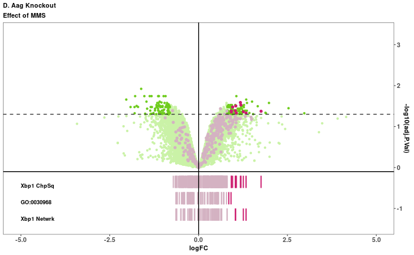

```r
vp2
```

### Panels combined

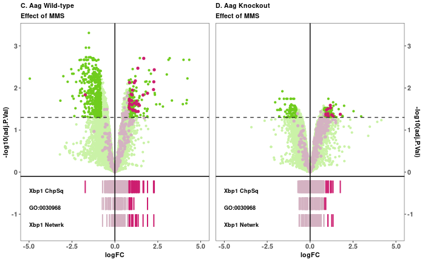

```r
gridExtra::grid.arrange(vp1, vp2, nrow=1)
```

```r
pdf.file.volcano <- "Figure_1_CD.pdf"
pdf(file=pdf.file.volcano, paper="a4", width=11.3/2.54, height=8/2.54, useDingbats=F)
gridExtra::grid.arrange(vp1, vp2, nrow=1)
dev.off()
```

null device 1

```r
cat("Saved:", pdf.file.volcano)
```

```
Saved: Figure_1_CD.pdf
```

## Session info

```r
cat("Date:", format(Sys.time(), "%a %d-%b-%Y %H:%M:%S"), "<br>\n")
```

Date: Mon 21-Jun-2021 08:29:05

|  | setting | value |
| --- | --- | --- |
| version | version | R version 3.6.1 (2019-07-05) |
| os | os | CentOS Linux 7 (Core) |
| system | system | x86_64, linux-gnu |
| ui | ui | RStudio |
| language | language | (EN) |
| collate | collate | en_GB.UTF-8 |
| ctype | ctype | en_GB.UTF-8 |
| tz | tz | Europe/London |
| date | date | 2021-06-21 |